# Assignment 2

#### 4.4

In 4.4, How many of the top 250 films have a score of 8.4 or greater?

```r
rating <- IMDB[grep("ratings", IMDB)]       #retrieving all the movie ratings
ratingScore <- gsub('.*">|</strong>' ,'', rating)  #retrieving only the rating
ratingScore <- ratingScore[-c(251:252)]   #removing last to values
X<-ratingScore >= 8.4      #filtering the rating more then 8.4
sum(X)        #number of films having rating 8.4 or greater
```

```
## [1] 66
```

There are **66** of the top 250 films have a score of 8.4 or greater

#### 4.5

In 4.5, What is the mean number of user ratings used to define the top 250 films?

```r
userrating<- grep("user rating", IMDB, value = T) #retrieving all the movie ratings and userratings
temp1 <- regexpr("( on )", userrating)    #returning vector indicating character position matching on
temp2 <- regexpr("( user )", userrating)  #returning vector indicating character position matching user
temp <-substr(userrating, temp1+4, temp2-1) #retrieving on the user rating
temp<- gsub("," , "", temp)   #removing comma
cat("Mean number of user rating is:",mean(as.numeric(temp)),"\n") #printing mean of the user rating
```

```
## Mean number of user rating is: 502449.8
```

### Question 5

#### 5.1

In 5.1, Read the dataset in and call it dublin. Assign to the dublin object the classes pop.data and data.frame (in that order). (The read.csv() function is the best way to read in the data.)

```r
setwd("C:/Users/anvit/OneDrive/Desktop/CA2 R")  #changing my directory where my files are located
dublin<-read.csv(file="Dublin.csv",header =TRUE, row.names = 1)   #read the csv file
class(dublin)<-c("pop.data","data.frame") #assigning dublin to classes pop.data and data.frame
class(dublin)
```

```
## [1] "pop.data"   "data.frame"
```

#### 5.2

In 5.2, Write an S3 summary method for an object of class pop.data which displays the following statistical summaries for the Male and the Female variables: minimum, max- imum, and mean population count. The years corresponding to the minima and max- ima should also be printed for both variables. This summary should be neat and clear, and easy to read and understand.

```r
summary.pop.data <- function(data) {  #creating function summary to display all the summaries asked in question
  cat("Year:",rownames(data)[data$Male == max(data$Male)],"Maximum Of Males:",max(data$Male),"\n")
  cat("Year:",rownames(data)[data$Male == min(data$Male)],"Minimum Of Males:",min(data$Male),"\n")
  cat("Year:",rownames(data)[data$Female == max(data$Female)],"Maximum Of Females:",max(data$Female),"\n")
  cat("Year:",rownames(data)[data$Female == min(data$Female)],"Minimum Of Females:",min(data$Female),"\n")
  cat("Mean Of Males:",mean(data$Male),"\n")
  cat("Mean Of Females:",mean(data$Female),"\n")
  cat("Mean Of Total Population:",mean(data$Total),"\n")
}
```

#### 5.3

In 5.3, Test your summary method by running the code summary(dublin).

```r
summary(dublin)
```

```
## Year: 2016 Maximum Of Males: 658371
## Year: 1841 Minimum Of Males: 170930
## Year: 2016 Maximum Of Females: 688988
## Year: 1841 Minimum Of Females: 201843
## Mean Of Males: 360233.6
## Mean Of Females: 394663.3
## Mean Of Total Population: 754897
```

#### 5.4

In 5.4, Create an S3 plot method for the class pop.data that produces the following plot:

- A line plot (a time series plot) containing two lines to show the population trend for males and females
- By default, the plot will draw a red line for males and a blue line for females - the user must be able to change these colours if desired
- The plot must include meaningful labels for the axis and legend
- The plot should be neat and clear and be easy to interpret - pay attention to distances between the plot edge and the plotting panel on all sides, the orientation of numbers, the position of titles, the default width of lines on the plot etc.
- The method should also include a generic title by default, but allow the user to include their own title as an argument if desired.
- Your code should not `hard-code’ numbers into it unnecessarily - e.g., if a longer or shorter dataset is supplied to it, it should be able to plot this without any errors

```r
options(scipen=5) #changing the option settings to get the absolute value not e powers
plot.pop.data <- function(data, MaleColor, FemaleColor,title) {
  par(mar = c(6.5, 6.5, 2.5, 0.5), mgp = c(4.5, 1, 0),las=2) #setting the margins
  Year=rownames(data) #getting the rownames for axis setting
  #plotting the time series with male and female
  ts.plot(window(data$Male),
          window(data$Female),
          main=paste(title),
          gpars=list(xlab="Year",
                     ylab="Population Trends",
                     pch=200,
                     col=c(MaleColor, FemaleColor),
                     lwd=2,xaxt='n'))

  axis(1, at=1:length(Year), labels=Year) #setting the axis of plot
  legend("top",
         bty="n",
         c("Male", "Female"),
         lty=c(1, 1),
         lwd=c(2, 2),
         col=c(MaleColor, FemaleColor))}
```

#### 5.5

In 5.5, Test your plot method by running plot(dublin). Include a user-specified title relevant to this dataset in your arguments.

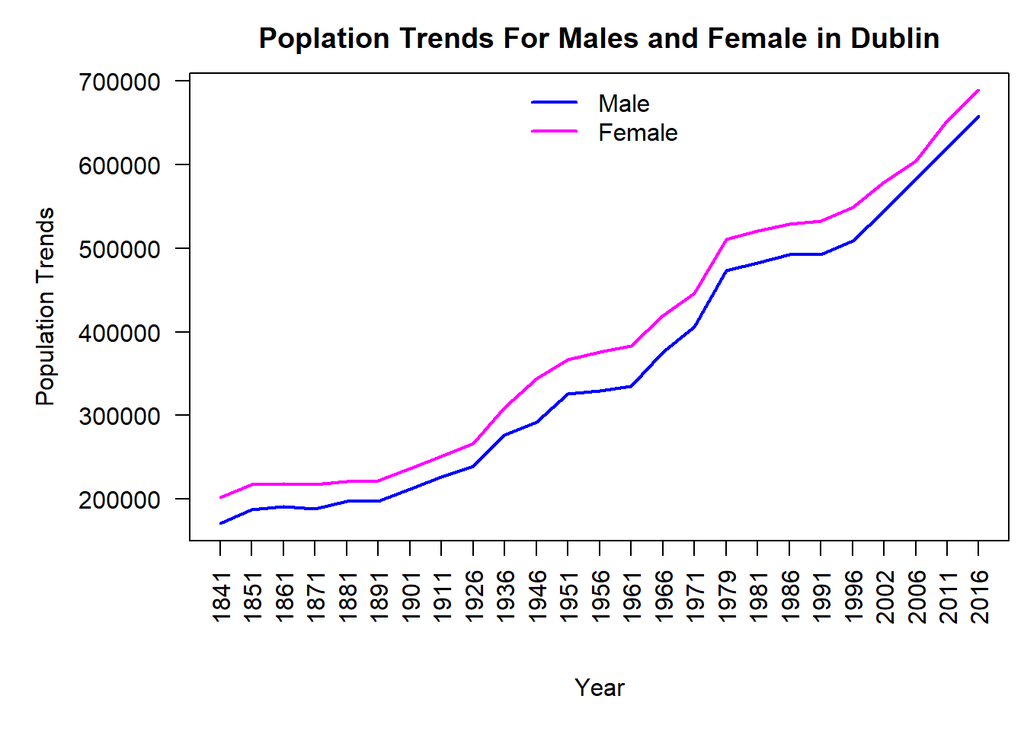

```r
plot(dublin, "4","6","Poplation Trends For Males and Female in Dublin")
```

#### 5.6

In 5.6, The file Mayo.csv contains similar information on population figures from 1861 to 2016 in the county of Mayo. Load the dataset, call it mayo, and assign it the two classes pop.data and data.frame as before. Run summary(mayo) and plot(mayo) to test your two methods (including an appropriate title for the plot). Interpret the findings, commenting on any differences or similarites between the two summaries and two plots.

```r
setwd("C:/Users/anvit/OneDrive/Desktop/CA2 R")
mayo<-read.csv(file="Mayo.csv",header =, row.names = 1)
class(mayo)<-c("pop.data","data.frame")
class(mayo)
```

```
## [1] "pop.data"   "data.frame"
```

```r
summary(mayo)
```

```
## Year: 1861 Maximum Of Males: 125636
## Year: 1991 Minimum Of Males: 55981
## Year: 1861 Maximum Of Females: 129160
## Year: 1971 Minimum Of Females: 53123
## Mean Of Males: 77196.22
## Mean Of Females: 76305.13
## Mean Of Total Population: 153501.3
```

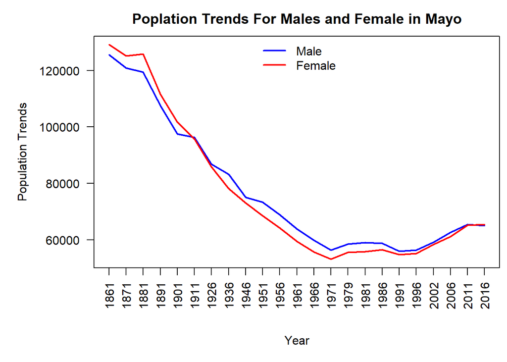

```r
plot(mayo,"blue","red","Poplation Trends For Males and Female in Mayo")
```